[figure not shown]

Simplocation

THERE IS NO MAGIC BULLET THAT WILL SOLVE THE HOUSING CRISIS.

Housing supply needs to increase so that more people can own a home for the first time.

Simplocation is useful for:

 Existing homeowners - people with mortgages;

 Property buyers and developers; and

 Professionals

For Home owners

Simplocation provides a handup to homeowners to get mortgage free faster and allows

potential buyers to access desirable land and own their own home without having to live in a

shoebox apartment.

Simplocation allows homeowner to learn about the development potential of their property at

a quick glance. With simplocation, no one needs to trawl through pages of the district plan

anymore.

With Simplocation, a homeowner simply types in their address and clicks search, and is shown

a dashboard of information unique to their land zone.

For Buyers

If you are a buyer, you’re currently restricted to existing homes or subdivisions. Simplocation

is a new property market for underutilised land.

With Simplocation, the buyer can search all properties in a specific area to identify which ones

can be subdivided; then approach the owner of the property to begin a process that will leave

both parties better off.

Background statistics:

Wellington region projection (Stats NZ datasets) for 2017-2038 proves surplus of the new

premises needs and market capacity:

Population growth

49.6 K.

around 0.5% yearly growth

Households growth

16.5 K.

based on sub-national household

projections by regions (median)

In average that means that 3 people in average per household

Number of new dwellings consented

36 K.

based on 1.8 K. per year - regional new

dwellings data

The only limitation if the physical land utilisation and sub-divisible areas.

Benefits

With Simplocation, potential buyers and owners with surplus land are able to connect.

[figure not shown]

Buyers get a home of their own in a good location and owners gets to retire mortgage free.

Additionally, Simplocation is a great platform for professionals such as planners, builders and

bankers to market their services to potential clients.

New banking and legal products will help realise the full potential of Simplocation. We are

looking for investors to make Simplocation come to life.

Simplocation - more New Zealanders living in their own home.

Team Members

Andrew Sknar, Zac Clark, Reece Bassett, Daniel Cairns, Gabriel Brougham, Waruna Padmasiri,

Rayan Amarasekara, Weihong Jiang.

Data used

Source

Factors

Number series

scope

Fields

LINZ

geospatial

data

www.linz.govt.nz

Location by section

Restrictions (Statutory

Actions)

Static as at 22

July 2017 (5

days time lag)

 Area (polygon

– geospatial);

District Plan

www.wellington.go

vt.nz

2 layers of geospatial

data + district planner

rules:

Zoning by suburb

(actual zones – spatial

area);

Relevant provisions of

district plan.

Static/Actual

 Site coverage;

 Inner

residential

area,

 outer

residential

area %;

Quick stats

www.stats.govt.nz

Tenure of household

Yearly,

Quarterly

adjusted data;

Mortgage payments

made;

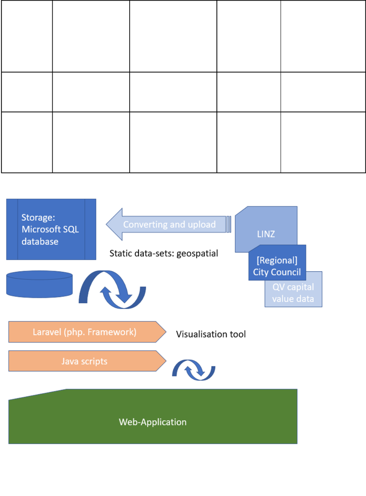

Mortgage payments

not made;

Total households in

dwellings owned or

partly owned.

Base map

http://js.api.here.c

om/v3/3.0/mapsjs-

core.js

Original View -

Wellington

Static

Geospatial - Location

Household

and

dwelling

projections

www.stats.govt.nz

Regional split: sub-

national household

projections by regions;

regional new dwellings

data;

Yearly adjusted

data.

Calculated

projections;

Figure 1: Solution Architecture Diagram

The solution consists of 5 main elements:

1. Row data feed from the open data sources: LINZ, Wellington City Council, Stats NZ;

2. Conversion and transformation of data for the Load;

3. SQL storage of the multiple factors data;

[figure not shown]

4. Laravel (php. Framework) is used to both: creation of the SQL platform and

visualisation linked to Maps; Java scripts developed to support data processing;

5. Web-Application representing the overlaid data on the Maps.

For the Proof of Concept the data used was restricted to a specific region.

Award Categories

Simplocation is entered in the following categories:

 Open Government: Simplocation uses data to help people to learn about the

development potential of their own property and the District Plan.

 Citizen Engagement: Simplocation allows citizens to engage with the District Plan in a

meaningful way.

 Data Journalism: Simplocation uses data visualisation tools in an interactive way to

make complex District Plan information accessible and understandable.

 Geospatial location: Simplocation uses HERE location capacilities for scalability, use

and API functionality.

 Re: invention: Simplication transforms delivers a more effective and engaging way of

interact the District Plan data.

 Sustainable New Zealand: Simplocation contributes to Goal 10: Reducing inequality

within and amongst countries and Goal 11: Sustainable Cities and Communities by

increasing housing supply and making housing more accessible.

Challenges Experienced

#

Challenge

Mitigation

1

Initial idea was to build a multi-factor definition (based on

a user Profile) of multiple layers of the location priorities.

Priorities can include: economic, social and infrastructural

factors. The representation of the heat-map would be

projected based on district data and combined in one

single map. The idea was challenged as too broad and

narrowing-down split the team.

Still using map as the

basis for visualisation;

Re-prioritisation of the

scope; narrowing the

analysis to the

subdivision of land in

Wellington region;

2

Framework based on here-maps was proven complex and

required adjustments; using the LINZ data to render the

section Polygons onto the Here-map.

Solved by not using API,

but using local storage of

data;

3

Statistical data on the sub-divisible parcels is insufficient

and would require geological (by elevations)/

infrastructural / construction assessment in each particular

case.

Percentage of the Site

coverage is used as first

approximation to

defining if the Parcel /

Block of land is

potentially sub-divisible.

4

There is no spatial split for open data related to the house

construction costs.

To limit the analysis by

the maps data (polygon

analysis).